# AFDMD-111 Estadística

Lectura de archivos en R

Jose Darwin Tinoco Montejo

20/09/2023

# Lectura de archivos en R

`R` puede leer una gran cantidad de archivos incluyendo archivos `.txt`, `.csv`, `.xls`, `.pdf`, etc. Mediante el uso del paquete `tabulizer` se pueden leer tablas que se encuentran en documentos `PDF`. En la siguiente actividad se instalará y cargará el paquete `tabulizer` mediante los comandos:

```r
install.packages("tabulizer", dependencies = TRUE)   # Instala tabulizer
library(tabulizer)                                   # Carga tabulizer
```

Posteriormente se leerá la tabla localizada en el archivo `seccion_calificacionesmsosa247.pdf` que se encuentra en la sección de **archivos** del *Teams* (lo anterior se puede hacer mediante el comando `extract_tables` del tabulizer). Una vez cargada la tabla que se llamará `tablaAlumnos` se realizarán las siguientes actividades:

```r
library(tabulizer)
library(DT)
tabla <- extract_tables("seccion_calificacionesmsosa247.pdf", output = "data.frame")
tabladf <- as.data.frame(tabla)
datatable(tabladf)
```

|  | No | Matricula | Nombre | Parcial | Parcial.1 | Ev. | Calif. |
| --- | --- | --- | --- | --- | --- | --- | --- |
| 1 | 1 | 150300135 | ALEJO ALEJANDRO / MIJARES | 8 | 7 | 7 | 7 |
| 2 | 2 | 150300161 | CAN BACAB / HECTOR ARTURO | 10 | 8 | 8 | 9 |
| 3 | 3 | 150300087 | CAN BACAB / SERGIO ANTONIO | 7 | 8 | 9 | 8 |
| 4 | 4 | 140300086 | CERVANTES VILLEGAS / ALAN JAIME | 0 | 0 | 0 | 0 |
| 5 | 5 | 150300109 | CONSTANTINO ISNEROS / MOISES | 9 | 9 | 6 | 8 |
| 6 | 6 | 150300170 | CORONA MERCADO / JESUS | 7 | 6 | 5 | 6 |
| 7 | 7 | 150300508 | DE LA CRUZ MARTÍNEZ / MAURICIO | 8 | 3 | 10 | 7 |
| 8 | 8 | 150300107 | GALINDO ARROYO / FERNANDO IVAN | 7 | 9 | 6 | 7 |
| 9 | 9 | 150300511 | GARCIA VAZQUEZ / BRANDO | 8 | 8 | 8 | 8 |
| 10 | 10 | 150300123 | GIL GUZMAN / GIOVANY | 8 | 3 | 10 | 7 |

[output cut: 14 more lines]

1.- Graficar `No` contra `Parcial 1`.

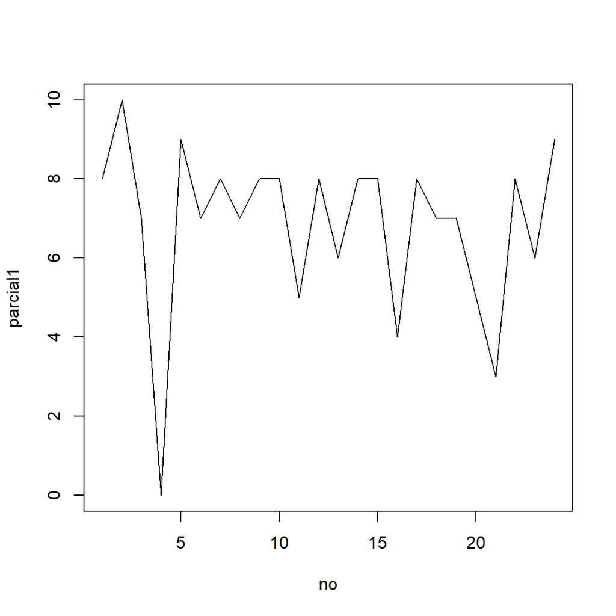

```r
no <- tabladf$No
parcial1 <- tabladf$Parcial
plot(no, parcial1, type = "l")
```

2.- Graficar `No` contra `Parcial 2`.

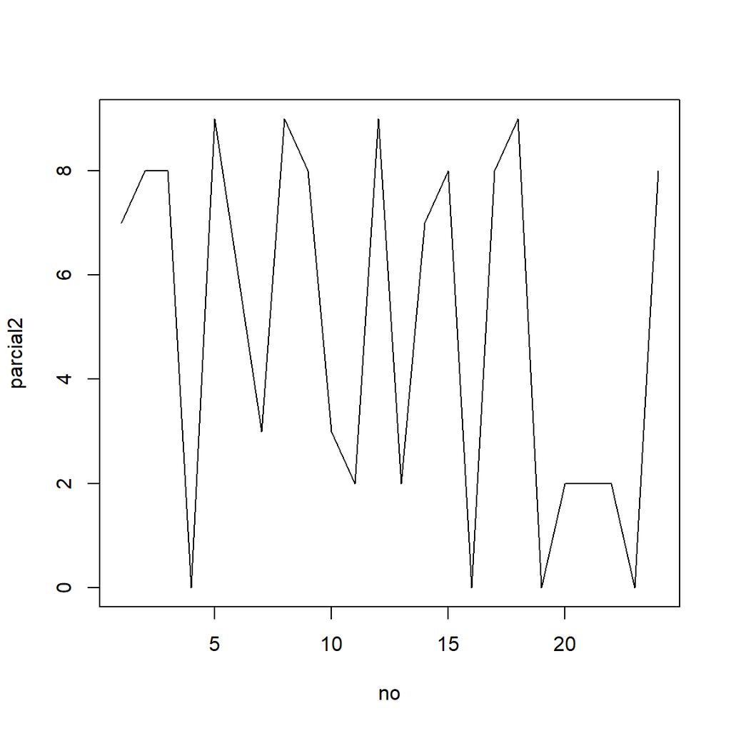

```r
parcial2 <- tabladf$Parcial.1
plot(no, parcial2, type = "l")
```

3.- Renombrar `Ev.` a `Parcial 3` (mostrar el `data.frame` resultante).

```r
colnames(tabladf)[4:6] <- c("Parcial1", "Parcial2", "Parcial3")
datatable(tabladf)
```

|  | No | Matricula | Nombre | Parcial1 | Parcial2 | Parcial3 | Calif. |
| --- | --- | --- | --- | --- | --- | --- | --- |
| 1 | 1 | 150300135 | ALEJO ALEJANDRO / MIJARES | 8 | 7 | 7 | 7 |
| 2 | 2 | 150300161 | CAN BACAB / HECTOR ARTURO | 10 | 8 | 8 | 9 |
| 3 | 3 | 150300087 | CAN BACAB / SERGIO ANTONIO | 7 | 8 | 9 | 8 |
| 4 | 4 | 140300086 | CERVANTES VILLEGAS / ALAN JAIME | 0 | 0 | 0 | 0 |
| 5 | 5 | 150300109 | CONSTANTINO ISNEROS / MOISES | 9 | 9 | 6 | 8 |
| 6 | 6 | 150300170 | CORONA MERCADO / JESUS | 7 | 6 | 5 | 6 |
| 7 | 7 | 150300508 | DE LA CRUZ MARTÍNEZ / MAURICIO | 8 | 3 | 10 | 7 |
| 8 | 8 | 150300107 | GALINDO ARROYO / FERNANDO IVAN | 7 | 9 | 6 | 7 |
| 9 | 9 | 150300511 | GARCIA VAZQUEZ / BRANDO | 8 | 8 | 8 | 8 |
| 10 | 10 | 150300123 | GIL GUZMAN / GIOVANY | 8 | 3 | 10 | 7 |

[output cut: 14 more lines]

4.- Graficar `No` contra `Parcial 1`, `Parcial 2`.

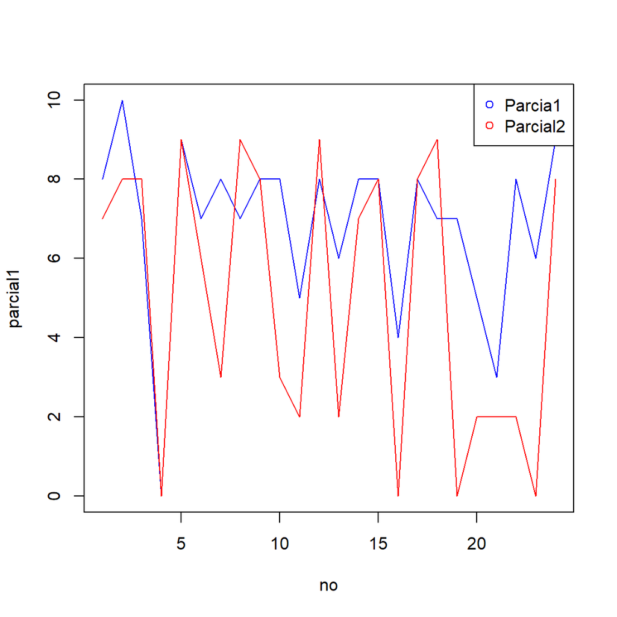

```r
plot(no, parcial1, type = "l", col = "blue")
lines(no, parcial2, type = "l", col = "red")
legend("topright", legend = c("Parcia1", "Parcial2"), col = c("blue", "red"), pch = c(1, 1))
```

5.- ¿Cuál es la media de las calificaciones finales? ¿Quién obtuvo la calificación más baja? ¿Quién obtuvo el mejor promedio? (anexar el código que lo calcula).

La media de calificación es:

```r
media <- mean(tabladf$Calif.)
media
```

```
[1] 5.958333
```

Las personas que obtuvieron las calificaciones más bajas son:

```r
min <- which(tabladf$Calif. == min(tabladf$Calif.))
nombres_min <- tabladf$Nombre[min]
nombres_min
```

```
[1] "CERVANTES VILLEGAS / ALAN JAIME" "PAT MAY / JOHANES BENJAMIN"
[3] "SALGADO GONZALEZ / ADAN OMAR"    "SÁNCHEZ PARTIDA / ALAN MISSAEL"
```

Las personas que obtuvieron las calificaciones más altas son:

```r
max <- which(tabladf$Calif. == max(tabladf$Calif.))
nombres_max <- tabladf$Nombre[max]
nombres_max
```

```
[1] "CAN BACAB / HECTOR ARTURO"          "HERNÁNDEZ VALENCIA / ESTEBAN RAMÓN"
```

6.- Cree una nueva columna llamada `promedio` (esto lo puede hacer con `mutate` del paquete `dplyr`) y compárela con la columna `Calif.` (¿Qué se puede observar?).

```r
library(dplyr)
promedio <- rowMeans(tabladf[, c("Parcial1", "Parcial2", "Parcial3")])
tabladf <- mutate(tabladf, Promedio = promedio)
datatable(tabladf)
```

|  | No | Matricula | Nombre | Parcial1 | Parcial2 | Parcial3 | Calif. | Promedio |
| --- | --- | --- | --- | --- | --- | --- | --- | --- |
| 1 | 1 | 150300135 | ALEJO ALEJANDRO / MIJARES | 8 | 7 | 7 | 7 | 7.333333333333333 |
| 2 | 2 | 150300161 | CAN BACAB / HECTOR ARTURO | 10 | 8 | 8 | 9 | 8.666666666666666 |
| 3 | 3 | 150300087 | CAN BACAB / SERGIO ANTONIO | 7 | 8 | 9 | 8 | 8 |
| 4 | 4 | 140300086 | CERVANTES VILLEGAS / ALAN JAIME | 0 | 0 | 0 | 0 | 0 |
| 5 | 5 | 150300109 | CONSTANTINO ISNEROS / MOISES | 9 | 9 | 6 | 8 | 8 |
| 6 | 6 | 150300170 | CORONA MERCADO / JESUS | 7 | 6 | 5 | 6 | 6 |
| 7 | 7 | 150300508 | DE LA CRUZ MARTÍNEZ / MAURICIO | 8 | 3 | 10 | 7 | 7 |
| 8 | 8 | 150300107 | GALINDO ARROYO / FERNANDO IVAN | 7 | 9 | 6 | 7 | 7.333333333333333 |
| 9 | 9 | 150300511 | GARCIA VAZQUEZ / BRANDO | 8 | 8 | 8 | 8 | 8 |
| 10 | 10 | 150300123 | GIL GUZMAN / GIOVANY | 8 | 3 | 10 | 7 | 7 |

[output cut: 14 more lines]

Se puede observar que, la columna “Calif.” también calcula el promedio de los tres parciales, sin embargo, redondean los decimales, a comparación de la nueva columna que agregamos, en donde NO se redondean los decimales

Posteriormente lea el archivo `it0103_2016_01.csv` (lo puede hacer mediante el comando `read.csv()`) el cual es una versión `sucia` del archivo anterior y replique cada uno de los puntos de arriba (sí es necesario modifique el data.frame resultante).

```r
excel <- read.csv("it0103_2016_01.csv")
exceldf <- as.data.frame(excel)
datatable(exceldf)
```

|  | No | Matricula | Nombre | Calif. | Examen | Calificacion |
| --- | --- | --- | --- | --- | --- | --- |
| 1 | 1 | 150300135 | ALEJO ALEJANDRO / MIJARES | 7 | Parcial1 | 8 |
| 2 | 2 | 150300161 | CAN BACAB / HECTOR ARTURO | 9 | Parcial1 | 10 |
| 3 | 3 | 150300087 | CAN BACAB / SERGIO ANTONIO | 8 | Parcial1 | 7 |
| 4 | 4 | 140300086 | CERVANTES VILLEGAS / ALAN JAIME | 0 | Parcial1 | 0 |
| 5 | 5 | 150300109 | CONSTANTINO ISNEROS / MOISES | 8 | Parcial1 | 9 |
| 6 | 6 | 150300170 | CORONA MERCADO / JESUS | 6 | Parcial1 | 7 |
| 7 | 7 | 150300508 | DE LA CRUZ MARTÍNEZ / MAURICIO | 7 | Parcial1 | 8 |
| 8 | 8 | 150300107 | GALINDO ARROYO / FERNANDO IVAN | 7 | Parcial1 | 7 |
| 9 | 9 | 150300511 | GARCIA VAZQUEZ / BRANDO | 8 | Parcial1 | 8 |
| 10 | 10 | 150300123 | GIL GUZMAN / GIOVANY | 7 | Parcial1 | 8 |

[output cut: 62 more lines]

```r
excelno <- exceldf$No[1:24]
excelmatricula <- exceldf$Matricula[1:24]
excelnombre <- exceldf$Nombre[1:24]
excelparcial1 <- exceldf$Calificacion[1:24]
excelparcial2 <- exceldf$Calificacion[25:48]
excelparcial3 <- exceldf$Calificacion[49:72]
excelcalif. <- exceldf$Calif.[1:24]
```

1.- Graficar `No` contra `Parcial 1`.

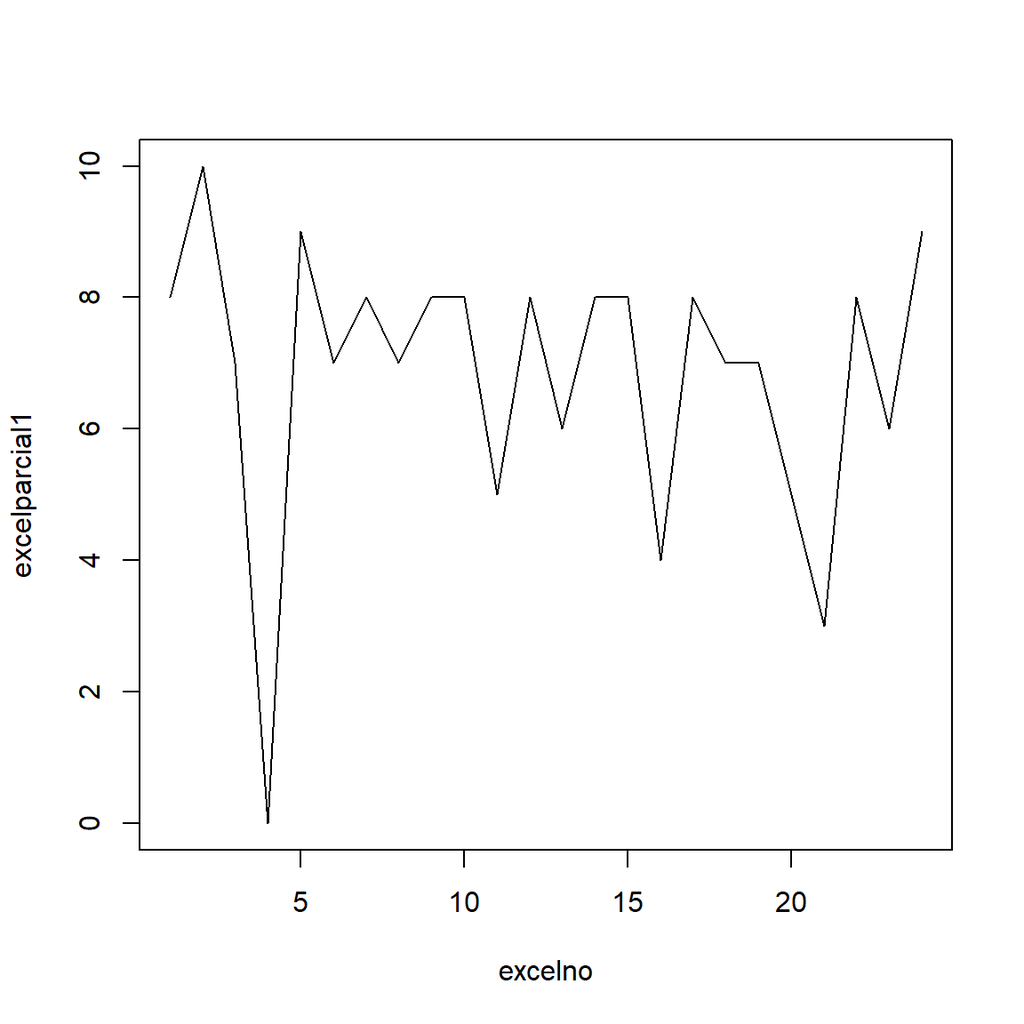

```r
plot(excelno, excelparcial1, type = "l")
```

2.- Graficar `No` contra `Parcial 2`.

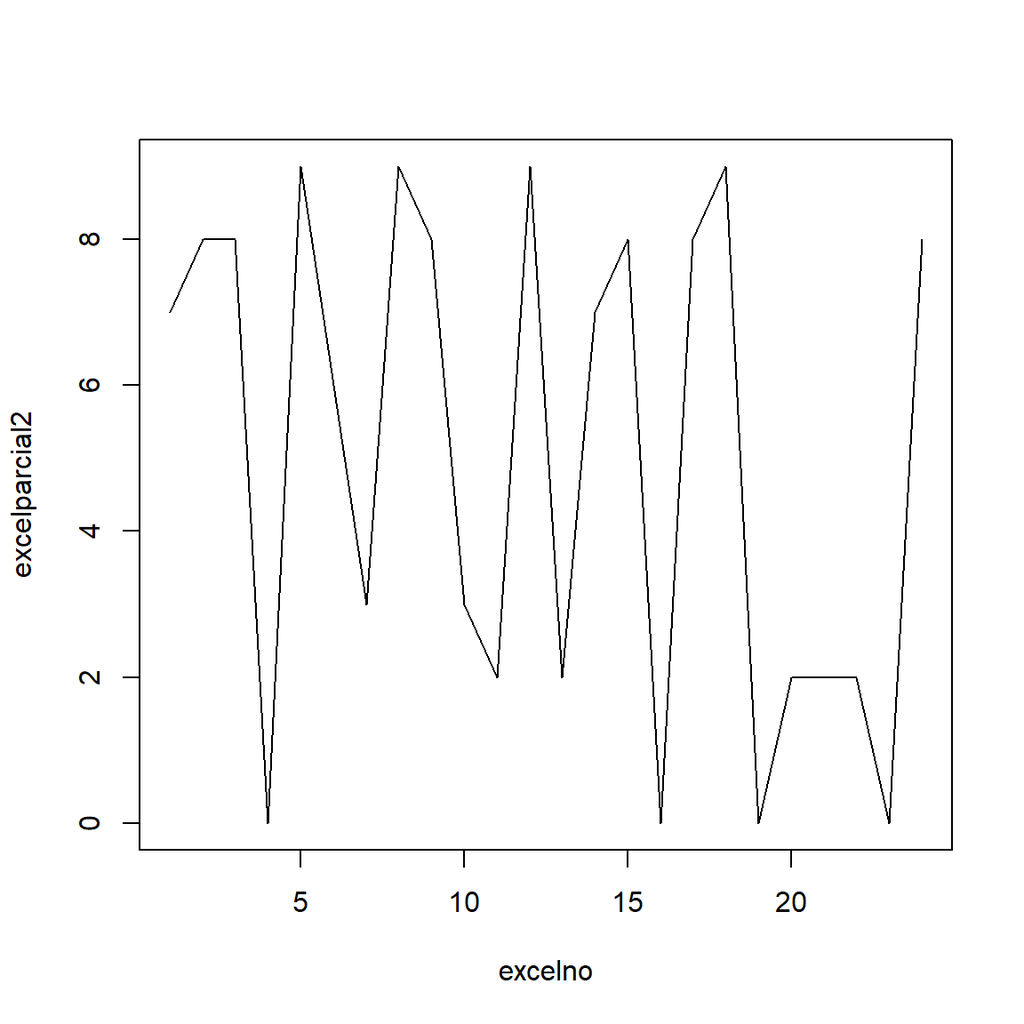

```r
plot(excelno, excelparcial2, type = "l")
```

3.- Renombrar `Ev.` a `Parcial 3` (mostrar el `data.frame` resultante).

```r
exceldf <- data.frame(
  No = excelno,
  Matricula = excelmatricula,
  Nombre = excelnombre,
  Parcial1 = excelparcial1,
  Parcial2 = excelparcial2,
  Parcial3 = excelparcial3,
  Calif. = excelcalif.
  )
  datatable(exceldf)
```

|  | No | Matricula | Nombre | Parcial1 | Parcial2 | Parcial3 | Calif. |
| --- | --- | --- | --- | --- | --- | --- | --- |
| 1 | 1 | 150300135 | ALEJO ALEJANDRO / MIJARES | 8 | 7 | 7 | 7 |
| 2 | 2 | 150300161 | CAN BACAB / HECTOR ARTURO | 10 | 8 | 8 | 9 |
| 3 | 3 | 150300087 | CAN BACAB / SERGIO ANTONIO | 7 | 8 | 9 | 8 |
| 4 | 4 | 140300086 | CERVANTES VILLEGAS / ALAN JAIME | 0 | 0 | 0 | 0 |
| 5 | 5 | 150300109 | CONSTANTINO ISNEROS / MOISES | 9 | 9 | 6 | 8 |
| 6 | 6 | 150300170 | CORONA MERCADO / JESUS | 7 | 6 | 5 | 6 |
| 7 | 7 | 150300508 | DE LA CRUZ MARTÍNEZ / MAURICIO | 8 | 3 | 10 | 7 |
| 8 | 8 | 150300107 | GALINDO ARROYO / FERNANDO IVAN | 7 | 9 | 6 | 7 |
| 9 | 9 | 150300511 | GARCIA VAZQUEZ / BRANDO | 8 | 8 | 8 | 8 |
| 10 | 10 | 150300123 | GIL GUZMAN / GIOVANY | 8 | 3 | 10 | 7 |

[output cut: 14 more lines]

4.- Graficar `No` contra `Parcial 1`, `Parcial 2`.

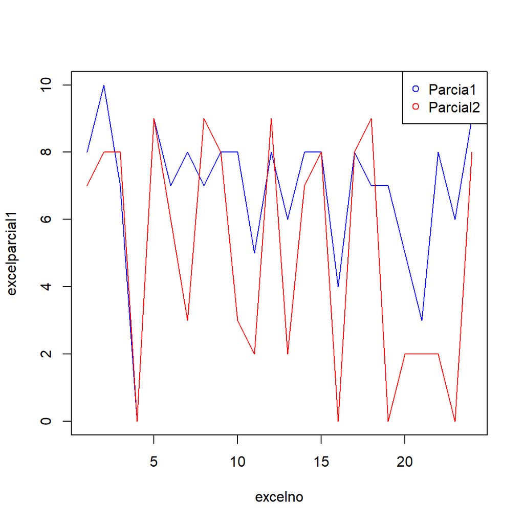

```r
plot(excelno, excelparcial1, type = "l", col = "blue")
lines(excelno, excelparcial2, type = "l", col = "red")
legend("topright", legend = c("Parcia1", "Parcial2"), col = c("blue", "red"), pch = c(1, 1))
```

5.- ¿Cuál es la media de las calificaciones finales? ¿Quién obtuvo la calificación más baja? ¿Quién obtuvo el mejor promedio? (anexar el código que lo calcula).

La media de calificación es:

```r
excelmedia <- mean(exceldf$Calif.)
excelmedia
```

```
[1] 5.958333
```

Las personas que obtuvieron las calificaciones más bajas son:

```r
excelmin <- which(exceldf$Calif. == min(exceldf$Calif.))
excelnombres_min <- exceldf$Nombre[min]
excelnombres_min
```

```
[1] "CERVANTES VILLEGAS / ALAN JAIME " "PAT MAY / JOHANES BENJAMIN "
[3] "SALGADO GONZALEZ / ADAN OMAR "    "SÁNCHEZ PARTIDA / ALAN MISSAEL "
```

Las personas que obtuvieron las calificaciones más altas son:

```r
excelmax <- which(exceldf$Calif. == max(exceldf$Calif.))
excelnombres_max <- exceldf$Nombre[max]
excelnombres_max
```

```
[1] "CAN BACAB / HECTOR ARTURO "          "HERNÁNDEZ VALENCIA / ESTEBAN RAMÓN "
```

6.- Cree una nueva columna llamada `promedio` (esto lo puede hacer con `mutate` del paquete `dplyr`) y compárela con la columna `Calif.`

```r
excelpromedio <- rowMeans(exceldf[, c("Parcial1", "Parcial2", "Parcial3")])
exceldf <- mutate(exceldf, Promedio = excelpromedio)
datatable(exceldf)
```

|  | No | Matricula | Nombre | Parcial1 | Parcial2 | Parcial3 | Calif. | Promedio |
| --- | --- | --- | --- | --- | --- | --- | --- | --- |
| 1 | 1 | 150300135 | ALEJO ALEJANDRO / MIJARES | 8 | 7 | 7 | 7 | 7.333333333333333 |
| 2 | 2 | 150300161 | CAN BACAB / HECTOR ARTURO | 10 | 8 | 8 | 9 | 8.666666666666666 |
| 3 | 3 | 150300087 | CAN BACAB / SERGIO ANTONIO | 7 | 8 | 9 | 8 | 8 |
| 4 | 4 | 140300086 | CERVANTES VILLEGAS / ALAN JAIME | 0 | 0 | 0 | 0 | 0 |
| 5 | 5 | 150300109 | CONSTANTINO ISNEROS / MOISES | 9 | 9 | 6 | 8 | 8 |
| 6 | 6 | 150300170 | CORONA MERCADO / JESUS | 7 | 6 | 5 | 6 | 6 |
| 7 | 7 | 150300508 | DE LA CRUZ MARTÍNEZ / MAURICIO | 8 | 3 | 10 | 7 | 7 |
| 8 | 8 | 150300107 | GALINDO ARROYO / FERNANDO IVAN | 7 | 9 | 6 | 7 | 7.333333333333333 |
| 9 | 9 | 150300511 | GARCIA VAZQUEZ / BRANDO | 8 | 8 | 8 | 8 | 8 |
| 10 | 10 | 150300123 | GIL GUZMAN / GIOVANY | 8 | 3 | 10 | 7 | 7 |

[output cut: 14 more lines]